# FlexR

Sean Kiah, Yunshu Qiu, Letacianna Stoudmire

2023-11-17

## Introduction

Muscle force is a result of two important factors, the length of contraction and the speed of contraction. The force-length relationship governs that muscles generate the most amount of force when at their resting length and generate the least amount of force when they are shortened or elongated from their ideal resting length. This is a result of the cross-bridge theory and where each individual sarcomere has a limited attachment zone between actin and myosin. When muscles have increased and decreased length from their resting position, the amount of actin and myosin overlap is less resulting in decreased productions of force Rassier (2008). This project seeks to answer whether this typical force-length relationship is observed both under control and when the muscle is fatigued. It also seeks to answer whether there is a shift in the angle of the elbow joint at which the maximum voluntary contraction occurs under control and fatigued conditions. Previous studies have shown that fatigued muscles favor longer lengths for force generation over control muscles. Data was collected and analyzed to further test and answer these questions Biewener (2006).

## Methods

To find the force-length relationship for both control and fatigued muscles, we first needed to discover how we will control the length of contractions for the arm muscles. To do this we constructed a goniometer out of cardboard to measure the angle of contractions (angle of the upper arm and forearm via the elbow joint). Larger angles would have a longer length and smaller angles would have a shorter length. We measured 11 angles from 157.5 degrees to 45 degrees in 11.25 degree increments. At each angle we would produce the maximum voluntary contraction for 30 seconds and measure the output using a 40 kilogram load cell with a HX711 amplifier and an Arduino microcontroller. For our fatigued data we would use a backpack filled with textbooks to eccentrically fatigue our forearm flexors. The bag was lowered using the study arm until it was fully extended in 3-4 second cycles and returned to the top using the non-study hand. These cycles were repeated for 4 minutes, and after a 2 minute break data was collected again using the same method as in the control data. To analyze our data, we found the maximum voluntary contraction for all the angles of the experiments. This value is what we call Fmax. We then use this value to normalize all of our other values by dividing each maximum force for each angle by Fmax. We then plotted the control and fatigue data on the same graph so we could see the shift in Fmax as a result of fatiguing the forearm flexors. The best fitting model was determined by AICc values. This shift was then calculated by subtracting the two angles. An ANOVA test was used to see if it was significant.

## Results

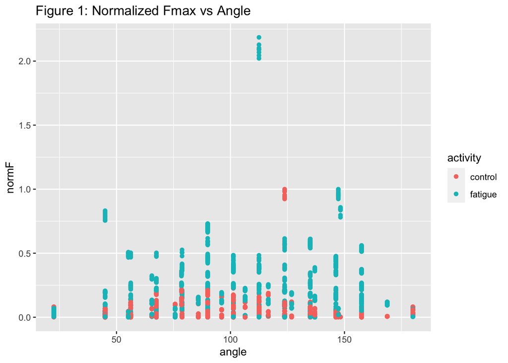

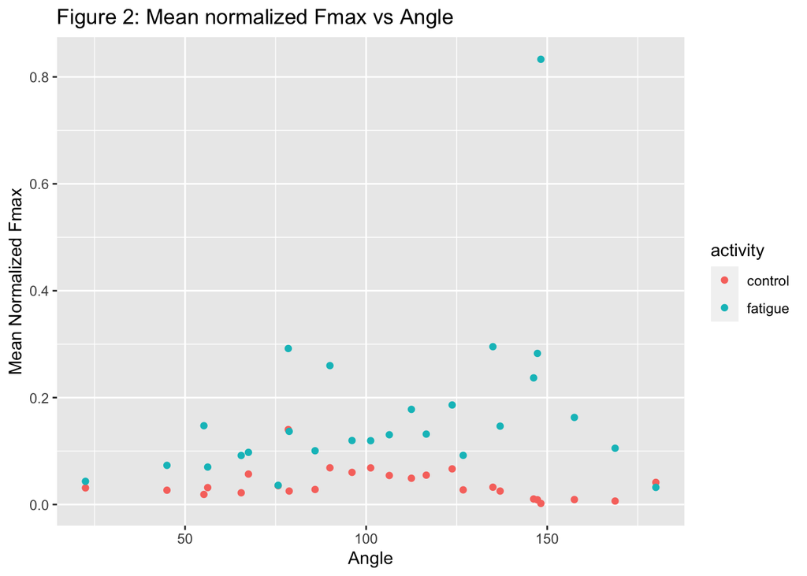

[output not shown]

```
##
##
## Table: Table 1: AIC values for 2nd, 3rd, and 4th order models
##
## |who        |activity |model |         AICc|
## |:----------|:--------|:-----|------------:|
## |Audrey     |control  |m2    |  -376.365589|
## |Audrey     |control  |m3    |  -375.612845|
## |Audrey     |control  |m4    |  -382.559103|
## |Audrey     |fatigue  |m2    |   115.398060|
## |Audrey     |fatigue  |m3    |   113.699932|
## |Audrey     |fatigue  |m4    |   115.177255|
## |Baylie     |control  |m2    |  -558.176705|
## |Baylie     |control  |m3    |  -626.899708|
## |Baylie     |control  |m4    |  -779.582585|
## |Baylie     |fatigue  |m2    |  -409.643400|
## |Baylie     |fatigue  |m3    |  -455.442116|
## |Baylie     |fatigue  |m4    |  -524.565948|
## |Jaan       |control  |m2    | -1348.332630|
## |Jaan       |control  |m3    | -1664.284227|
## |Jaan       |control  |m4    | -1698.001689|
## |Jaan       |fatigue  |m2    |  -954.477601|
## |Jaan       |fatigue  |m3    | -1042.353331|
## |Jaan       |fatigue  |m4    | -1042.658832|
## |Julia      |control  |m2    |  -758.701237|
## |Julia      |control  |m3    |  -938.397643|
## |Julia      |control  |m4    |  -951.668173|
## |Julia      |fatigue  |m2    |  -645.804270|
## |Julia      |fatigue  |m3    |  -724.990221|
## |Julia      |fatigue  |m4    |  -725.031387|
## |Lauren     |control  |m2    | -1584.321956|
## |Lauren     |control  |m3    | -1590.811044|
## |Lauren     |control  |m4    | -1650.996099|
## |Lauren     |fatigue  |m2    |   -24.679725|
## |Lauren     |fatigue  |m3    |   -39.658276|
## |Lauren     |fatigue  |m4    |   -38.791047|
## |Leo        |control  |m2    |  -720.558228|
## |Leo        |control  |m3    |  -759.575236|
## |Leo        |control  |m4    |  -804.176236|
## |Leo        |fatigue  |m2    |  -366.883703|
```

[output cut: 104 more lines]

```
## |sean       |fatigue  |m2    |  -210.522858|
## |sean       |fatigue  |m3    |  -225.815399|
## |sean       |fatigue  |m4    |  -230.445686|
## |vanessa    |control  |m2    |  -356.327991|
## |vanessa    |control  |m3    |  -365.169974|
## |vanessa    |control  |m4    |  -570.312613|
## |vanessa    |fatigue  |m2    |  -107.265508|
## |vanessa    |fatigue  |m3    |  -105.642975|
## |vanessa    |fatigue  |m4    |  -111.875937|
## |yunshu     |control  |m2    |     6.457814|
## |yunshu     |control  |m3    |   -21.826106|
## |yunshu     |control  |m4    |   -19.827343|
## |yunshu     |fatigue  |m2    |  -401.439282|
## |yunshu     |fatigue  |m3    |  -468.364262|
## |yunshu     |fatigue  |m4    |  -577.655416|
```

```
## # A tibble: 153 × 4
## # Groups:   who, activity [51]
##    who    activity model theta_max
##    <chr>  <chr>    <chr>     <dbl>
##  1 Audrey control  m2         90.8
##  2 Audrey control  m3        101.
##  3 Audrey control  m4        100.
##  4 Audrey fatigue  m2        108.
##  5 Audrey fatigue  m3        118.
##  6 Audrey fatigue  m4        114.
##  7 Baylie control  m2        158.
##  8 Baylie control  m3         62.9
##  9 Baylie control  m4         87.5
## 10 Baylie fatigue  m2        102.
## # ℹ 143 more rows
```

```
## # A tibble: 51 × 5
## # Groups:   who, activity [51]
##    who    activity model theta_max    AICc
##    <chr>  <chr>    <chr>     <dbl>   <dbl>
##  1 Audrey control  m4        100.   -383.
##  2 Audrey fatigue  m3        118.    114.
##  3 Baylie control  m4         87.5  -780.
##  4 Baylie fatigue  m4        110.   -525.
##  5 Jaan   control  m4         83.4 -1698.
##  6 Jaan   fatigue  m4         93.1 -1043.
##  7 Julia  control  m4         86.1  -952.
##  8 Julia  fatigue  m4         96.7  -725.
##  9 Lauren control  m4        110.  -1651.
## 10 Lauren fatigue  m3        132.    -39.7
## # ℹ 41 more rows
```

Table 2: Best fitting model due to lowest AICc value and predicted theta max

| who | activity | model | theta_max | AICc |
| --- | --- | --- | --- | --- |
| Audrey | control | m4 | 99.95495 | -382.55910 |
| Audrey | fatigue | m3 | 118.19820 | 113.69993 |
| Baylie | control | m4 | 87.45495 | -779.58258 |
| Baylie | fatigue | m4 | 109.52703 | -524.56595 |
| Jaan | control | m4 | 83.40090 | -1698.00169 |
| Jaan | fatigue | m4 | 93.08559 | -1042.65883 |
| Julia | control | m4 | 86.10360 | -951.66817 |
| Julia | fatigue | m4 | 96.68919 | -725.03139 |
| Lauren | control | m4 | 109.52703 | -1650.99610 |
| Lauren | fatigue | m3 | 132.38739 | -39.65828 |
| Leo | control | m4 | 92.40991 | -804.17624 |
| Leo | fatigue | m3 | 98.71622 | -366.98641 |
| Susanne | control | m3 | 77.54505 | -964.72383 |
| Susanne | fatigue | m4 | 157.50000 | -593.47309 |
| Tara | control | m4 | 87.56757 | -934.31031 |
| Tara | fatigue | m3 | 126.30631 | -602.36697 |
| alex | control | m4 | 95.45045 | -532.80020 |
| alex | fatigue | m4 | 107.72523 | -585.70371 |
| ana | control | m4 | 103.67117 | -977.06284 |
| ana | fatigue | m4 | 45.00000 | -55.61746 |
| andrew | control | m4 | 96.46396 | -524.66318 |
| andrew | fatigue | m4 | 110.87838 | -356.47957 |
| ben | control | m4 | 96.12613 | -2016.35692 |
| ben | fatigue | m4 | 105.92342 | -1596.58512 |
| conor | control | m3 | 116.39640 | -415.39930 |
| conor | fatigue | m4 | 157.50000 | -351.73117 |
| elisabeth | control | m4 | 98.26577 | -3931.21843 |
| elisabeth | fatigue | m4 | 146.68919 | -2192.05533 |
| elizabeth | control | m4 | 89.03153 | -366.54827 |
| elizabeth | fatigue | m4 | 102.88288 | -195.78231 |
| georgia | control | m4 | 89.70721 | -875.99537 |
| georgia | fatigue | m4 | 114.14414 | -396.51872 |
| hannah | control | m4 | 97.81532 | -502.79531 |
| hannah | fatigue | m4 | 108.28829 | -307.31837 |
| jess | control | m4 | 88.91892 | -2820.69434 |
| jess | fatigue | m4 | 45.00000 | -1303.66811 |
| jonah | control | m4 | 56.93694 | -984.29263 |
| jonah | fatigue | m3 | 97.92793 | -745.20491 |
| katie | control | m4 | 104.79730 | -1495.47387 |
| katie | fatigue | m4 | 107.27477 | -739.94975 |
| letacianna | control | m4 | 93.87387 | -1790.28878 |
| michael | control | m4 | 97.02703 | -3558.83503 |
| michael | fatigue | m4 | 84.30180 | -2829.90169 |
| nicole | control | m4 | 98.37838 | -605.62968 |
| nicole | fatigue | m4 | 126.98198 | -443.22225 |
| sean | control | m4 | 92.97297 | -1506.37360 |
| sean | fatigue | m4 | 92.07207 | -230.44569 |
| vanessa | control | m4 | 104.34685 | -570.31261 |
| vanessa | fatigue | m4 | 101.19369 | -111.87594 |
| yunshu | control | m3 | 124.16667 | -21.82611 |
| yunshu | fatigue | m4 | 157.50000 | -577.65542 |

```
## Analysis of Variance Table
##
## Response: theta_max
##           Df  Sum Sq Mean Sq F value  Pr(>F)
## activity   1  2796.5 2796.49  5.8026 0.01981 *
## Residuals 49 23614.9  481.94
## ---
## Signif. codes:  0 '***' 0.001 '**' 0.01 '*' 0.05 '.' 0.1 ' ' 1
```

```
##
##
## Table: Table 3: Mean shift in theta max
##
## | mean.shift| se.shift|
## |----------:|--------:|
## |   14.77027| 5.455925|
```

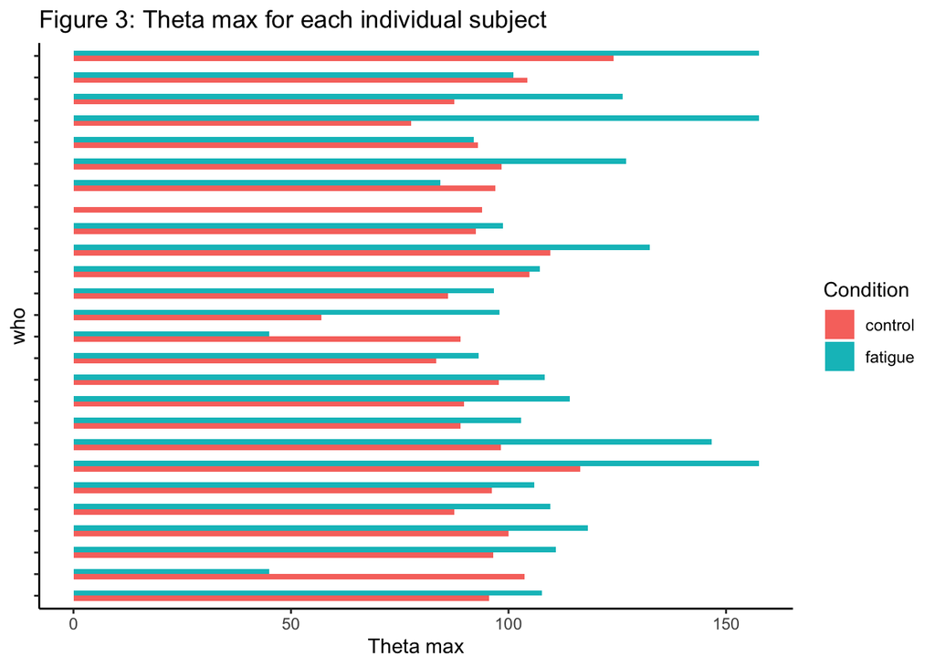

## References

Biewener, Ahn. 2006. “Tired or Fatigue? Factors Affecting the Force-Length Relationship of Muscle.” *Journal of Applied Physiology* 101 (1): 5–6.

Rassier, Herzog, Macintosh. 2008. “Length Dependence of Active Force Production in Skeletal Muscle.” *American Physiological Society* 86 (5): 1445–57.

Wan, Wang, Qin. 2017. “Muscle Fatigue: General Understanding and Treatment.” *Experimental & Moleculat Medicine* 49 (10): 384.